# Commonality analysis of the linear mixed models between each brain modality & mental health

Yue Wang and Narun P

22 Aug, 2023

```
##          used (Mb) gc trigger (Mb) limit (Mb) max used (Mb)
## Ncells 532391 28.5    1186411 63.4         NA   669411 35.8
## Vcells 988130  7.6    8388608 64.0     131072  1851587 14.2
```

## 0.1 Note

Here we use the ABCD release 4.0 data-set

# 1 Setting up the environment

## 1.1 Loading libraries

The following libraries and default settings were used during the analysis:

```r
options(scipen = 999)
#library("sva")
library(tidyverse)
library("tidymodels")
```

```r
##parallel map
library(partR2)
library(lme4)
library(yhat)
library(ggtext)
library(ggpubr)
library(cowplot)
library(partR2)
library(lme4)
library(yhat)
## library to tidy up the linear mixed models
library(sjPlot)
library("VennDiagram")
theme_set(theme_bw() + theme(panel.grid = element_blank()))
## parallel processing number of cores register
all_cores <- parallel::detectCores(logical = FALSE) - 5

doParallel::registerDoParallel(cores = all_cores)
```

## 1.2 Setting up path

We first loaded all of the relevant data files (not shown here as they refer to local directories):

## 1.3 load fitted results

### 1.3.1 load the mental health predicted results

```r
psy_pred <- readRDS(paste0(scriptfold,"Common_psy_gene_brain_all/saved_outputs/psychopathology_pls_pred_2.0.RData"))
```

### 1.3.2 load the computed gfactor

```r
gfactor_list <- readRDS(paste0(scriptfold,"genetics_psychopathology_common_scan_all_scripts/gfactor_scale_seperate.RData"))
```

```r
gfactor_baselie_test <- map(gfactor_list,"output_test_baseline")
gfactor_followup_test <- map(gfactor_list,"output_test_followup")
```

```r
subj_info <- c("SUBJECTKEY","SITE_ID_L","EVENTNAME")
```

Join predictions with subject information.

```r
pred_processing <- function(baseline_pred, followup_pred, baseline_table, followup_table,pred_name){
  names_vec <- c(subj_info,pred_name)

  baseline_subj_info <- baseline_table %>% select(all_of(subj_info))
  baseline_pred_vec <- baseline_pred %>% select(model_predict)
  baseline_output <- bind_cols(baseline_subj_info,baseline_pred_vec)
  names(baseline_output) <- names_vec

  followup_subj_info <- followup_table %>% select(all_of(subj_info))
  followup_pred_vec <- followup_pred %>% select(model_predict)
  followup_output <- bind_cols(followup_subj_info,followup_pred_vec)
  names(followup_output) <- names_vec

  output_all <- bind_rows(baseline_output,followup_output)
  return(list(baseline_output = baseline_output,
              followup_output = followup_output))
}
```

```r
processed_psy_results <- pmap(list(psy_pred[["baseline_test_pred"]],
                                   psy_pred[["baseline_test_data"]],
                                  psy_pred[["followup_test_pred"]],
                                  psy_pred[["followup_test_data"]]),
                             ~pred_processing(baseline_pred=..1,
                                              followup_pred=..3,
                                              baseline_table=..2,
                                              followup_table=..4,
                                              pred_name="psychopathology_pls"))
```

```r
site_char <- names(processed_psy_results)
```

### 1.3.3 prepocessing genetics prediction results

load in family index data

```r
ACS <-read_csv(paste0(datafolder,"ACSPSW03_DATA_TABLE.csv"))
#knitr::kable(glimpse(ACS))

#race_ethnicity
#1 = White; 2 = Black; 3 = Hispanic; 4 = Asian; 5 = Other

# guardian-report relationship
# Relationship of the participant in his or her family
# 0 = single; 1 = sibling; 2 = twin; 3 = triplet
# ACS %>% count(REL_RELATIONSHIP)

ACSselected <- ACS %>%
  select(SUBJECTKEY, EVENTNAME, SEX, INTERVIEW_AGE, RACE_ETHNICITY,
                              REL_FAMILY_ID, ACS_RAKED_PROPENSITY_SCORE) %>%
  mutate(RACE_ETHNICITY = recode_factor(as.factor(RACE_ETHNICITY),
                `1` = "White", `2` = "Black", `3` = "Hispanic", `4` = "Asian", `5` = "Other",
                .default = "White")) %>%
  mutate(SEX = as.factor(SEX)) %>%
  mutate(REL_FAMILY_ID = as.factor(REL_FAMILY_ID))

ACSselected %>%
 filter(EVENTNAME =="baseline_year_1_arm_1") %>%
 skimr::skim()
```

Data summary

| Name | Piped data |
| --- | --- |
| Number of rows | 11876 |
| Number of columns | 7 |
| _______________________ |  |
| Column type frequency: |  |
| character | 2 |
| factor | 3 |
| numeric | 2 |
| ________________________ |  |
| Group variables | None |

**Variable type: character**

| skim_variable | n_missing | complete_rate | min | max | empty | n_unique | whitespace |
| --- | --- | --- | --- | --- | --- | --- | --- |
| SUBJECTKEY | 0 | 1 | 12 | 16 | 0 | 11876 | 0 |
| EVENTNAME | 0 | 1 | 21 | 21 | 0 | 1 | 0 |

**Variable type: factor**

| skim_variable | n_missing | complete_rate | ordered | n_unique | top_counts |
| --- | --- | --- | --- | --- | --- |
| SEX | 0 | 1 | FALSE | 2 | M: 6196, F: 5680 |
| RACE_ETHNICITY | 2 | 1 | FALSE | 5 | Whi: 6180, His: 2411, Bla: 1784, Oth: 1247 |
| REL_FAMILY_ID | 0 | 1 | FALSE | 9854 | 373: 5, 749: 4, 11: 3, 400: 3 |

**Variable type: numeric**

| skim_variable | n_missing | complete_rate | mean | sd | p0 | p25 | p50 | p75 | p100 | hist |
| --- | --- | --- | --- | --- | --- | --- | --- | --- | --- | --- |
| INTERVIEW_AGE | 0 | 1 | 118.98 | 7.50 | 107.00 | 112.00 | 119.00 | 126.00 | 133.00 | ▇▆▆▆▆ |
| ACS_RAKED_PROPENSITY_SCORE | 0 | 1 | 691.34 | 350.98 | 161.36 | 449.35 | 619.31 | 821.74 | 1778.92 | ▅▇▂▂▁ |

```r
ACSselected_baseline <- ACSselected %>%
                        filter(EVENTNAME =="baseline_year_1_arm_1")%>%
                        select(SUBJECTKEY,REL_FAMILY_ID)
```

```r
enet_baseline <- readRDS(paste0(scriptfold,"stacking_gfactor_modelling/random_forest_data/random_forest_all_baseline_test.RDS"))

enet_followup <- readRDS(paste0(scriptfold,"stacking_gfactor_modelling/random_forest_data/random_forest_all_followup_test.RDS"))
```

Join the brain predictions with mental health.

Do not drop NA here, because a large numbers of participants are dropped.

Drop NA before the linear mixed models.

```r
join_gfactor_enet_psy <- function(site_input){
  enet_baseline_tibble <- enet_baseline[[site_input]]
  enet_followup_tibble <- enet_followup[[site_input]]
  psy_baseline_tibble <- processed_psy_results[[site_input]][["baseline_output"]]
  psy_followup_tibble <- processed_psy_results[[site_input]][["followup_output"]]

  enet_psy_baseline <- full_join(enet_baseline_tibble,psy_baseline_tibble, by =subj_info)
 enet_psy_followup <- full_join(enet_followup_tibble,psy_followup_tibble, by =subj_info)


  gfactor_baseline <- gfactor_baselie_test[[site_input]]
  gfactor_followup <- gfactor_followup_test[[site_input]]

  output_baseline <- full_join(enet_psy_baseline,gfactor_baseline,by="SUBJECTKEY")
  #%>% drop_na()
  output_followup <- full_join(enet_psy_followup,gfactor_followup,by="SUBJECTKEY")
  #%>%drop_na()
 output_all <- bind_rows(output_baseline,output_followup)

  return(list(baseline = output_baseline,
              followup=output_followup,
              all = output_all))

}
```

```r
gfactor_pred_enet <- map(.x = site_char,~join_gfactor_enet_psy(site_input = .x))

names(gfactor_pred_enet) <- site_char

gfactor_enet_pred_baseline <- map(gfactor_pred_enet,"baseline")
gfactor_enet_pred_followup <- map(gfactor_pred_enet,"followup")
gfactor_enet_baseline_followup <- map(gfactor_pred_enet,"all")


gfactor_enet_pred_baseline_table <- gfactor_enet_pred_baseline%>% do.call(rbind,.)
gfactor_enet_pred_followup_table <- gfactor_enet_pred_followup %>% do.call(rbind,.)
```

Processing the data across sites: mean centering.

sorting out the names

```r
brain_modality_names_namual <- tibble(tibble_names=c("DTI_data","rsmri_within_avg_data","smri_T2_mean_total_data","smri_T1_mean_total_data","Normalised_T2_","Avg_T2_Gray_","Avg_T2_White_","Normalised_T1_","Avg_T1_Gray_","Avg_T1_White_","Dest_Sulcal_Depth_","Dest_Vol_","Dest_Area_","Dest_Thick_","Vol_ASEG_","Avg_T2_ASEG_","Avg_T1_ASEG_Vol_","rsmri_gordon_aseg_data","incorrectgovsincorrectstop_ROI_","incorrectgovscorrectgo_ROI_","correctstopvsincorrectstop_ROI_","anystopvscorrectgo_ROI_","incorrectstopvscorrectgo_ROI_","correctstopvscorrectgo_ROI_","correctgovsfixation_ROI_","antiLargeLossVsSmallLoss_ROI_","antiSmallLossVsNeu_ROI_","antiLargeLossVsNeu_ROI_","antiLargeRewVsSmallRew_ROI_","antiSmallRewVsNeu_ROI_","antiLargeRewVsNeu_ROI_","feedPunPosVsNeg_ROI_","feedRewPosVsNeg_ROI_","antiLosVsNeu_ROI_","antiRewVsNeu_ROI_","posfacevsneutface_ROI_","negfacevsneutface_ROI_","facevsplace_ROI_","emotionvsneutface_ROI_","X2backvs0back_ROI_","emotion_ROI_","place_ROI_","X2back_ROI_","X0back_ROI_","rsmri_subnet" ) ,
label_names = c("DTI","rsmri_within_avg","smri_T2_mean_total","smri_T1_mean_total","Normalised_T2","Avg_T2_Gray","Avg_T2_White","Normalised_T1","Avg_T1_Gray","Avg_T1_White","Dest_Sulcal_Depth","Dest_Vol","Dest_Area","Dest_Thick","Vol_ASEG","Avg_T2_ASEG","Avg_T1_ASEG_Vol","rsmri_gordon_aseg","incorrectgovsincorrectstop","incorrectgovscorrectgo","correctstopvsincorrectstop","anystopvscorrectgo","incorrectstopvscorrectgo","correctstopvscorrectgo","correctgovsfixation","antiLargeLossVsSmallLoss","antiSmallLossVsNeu","antiLargeLossVsNeu","antiLargeRewVsSmallRew","antiSmallRewVsNeu","antiLargeRewVsNeu","feedPunPosVsNeg","feedRewPosVsNeg","antiLosVsNeu","antiRewVsNeu","posfacevsneutface","negfacevsneutface","facevsplace","emotionvsneutface","X2backvs0back","emotion","place","X2back","X0back","rsmri_subnet" ))
```

mean centering with in site

```r
#data_input <- gfactor_enet_pred_baseline[[1]]
#modality_input <- brain_modality_names_namual$tibble_names[1]

center_by_site <- function(data_input, modality_input){
  data_select <- data_input %>% select(all_of(subj_info),
                                       all_of(c(modality_input,"psychopathology_pls","gfactor")))%>%
                 drop_na()

  var_vec <- data_select[[modality_input]]
  mean_var_vec <- mean(var_vec)
  centered_var_vec <- var_vec -mean_var_vec
 var_tibble <- tibble(centered_var_vec,mean_var_vec)
 names(var_tibble) <- paste0(modality_input,c("_cws","_savg"))

 output_tibble <- bind_cols(data_select,var_tibble)

  output_tibble <- output_tibble %>%
    mutate(psy_savg = mean(psychopathology_pls))%>%
    mutate(psy_cws = psychopathology_pls-psy_savg)

return(output_tibble)
  }

#list_input <- gfactor_enet_pred_baseline
center_across_site <- function(list_input, modality_input){
  one_modality_cross_site <- list_input %>% map(.,~center_by_site(data_input=.,
                                                                  modality_input=modality_input))%>%
    do.call(rbind,.)

  one_modality_cross_site <- one_modality_cross_site %>%
                            left_join(ACSselected_baseline, by ="SUBJECTKEY")%>%
                            drop_na()
  return(one_modality_cross_site)
}


centered_cross_site_baseline <- brain_modality_names_namual$tibble_names%>%
                                map(.,~center_across_site(list_input = gfactor_enet_pred_baseline,
                                                          modality_input=.))

names(centered_cross_site_baseline) <- brain_modality_names_namual$tibble_names

centered_cross_site_followup <- brain_modality_names_namual$tibble_names%>%
                                map(.,~center_across_site(list_input = gfactor_enet_pred_followup,
                                                          modality_input=.))

names(centered_cross_site_followup) <- brain_modality_names_namual$tibble_names
```

### 1.4.1 commonality analysis of individual brain scan modalities against predictions

All the values of coefficients are taken averages across sites. Then process the data for interval plot. It is quite like the previous work.

Load the variable names

```r
enet_interval_names <- readxl::read_excel(paste0(scriptfold,"Common_psy_gene_brain_all/CommonalityPlotingNames.xlsx"))
```

compute the commonality metrics across individual modalities

```r
common_analysis_psy_brain_mod <- function(data_input=centered_cross_site_baseline[[modality_input]],
                                     modality_input){

  modality_savg <- paste0(modality_input,"_savg")
  modality_cws <- paste0(modality_input,"_cws")

 full_model <- as.formula(paste0("gfactor ~psy_savg+psy_cws+",modality_savg,"+",modality_cws,"+ (1|SITE_ID_L:REL_FAMILY_ID)"))

 modality_only_model <- as.formula(paste0("gfactor~",modality_savg,"+",modality_cws,"+(1|SITE_ID_L:REL_FAMILY_ID)"))

full_model <- lmer(full_model,data = data_input)
  rsq_full <- performance::r2(full_model)

  modality_model <- lmer(modality_only_model,data = data_input)
  rsq_modality <- performance::r2(modality_model)


 psy_model <- lmer(gfactor ~  psy_savg+psy_cws+ (1|SITE_ID_L:REL_FAMILY_ID),data = data_input)
 rsq_psy <- performance::r2(psy_model)

  unique_modality_margin <- rsq_full$R2_marginal-rsq_psy$R2_marginal

  unique_psy_margin <- rsq_full$R2_marginal-rsq_modality$R2_marginal

  common_psy_modality_margin <- rsq_modality$R2_marginal+rsq_psy$R2_marginal-rsq_full$R2_marginal

  output_tibble <- tibble(values=c(unique_modality_margin,
                                   unique_psy_margin,
                                   common_psy_modality_margin,
                                   rsq_full$R2_marginal),
                          modality = modality_input,
                          names = c(paste0("unique_", modality_input),
                                    "unique_psychopathology",
                                    "common",
                                    "total"))


  return(output_tibble)
  }


common_brain_baseline <- map2(.x = centered_cross_site_baseline,
                              .y = brain_modality_names_namual$tibble_names,
                              ~common_analysis_psy_brain_mod(data_input = .x,
                                                             modality_input = .y))


common_brain_followup <- map2(.x = centered_cross_site_followup,
                              .y = brain_modality_names_namual$tibble_names,
                              ~common_analysis_psy_brain_mod(data_input = .x,
                                                             modality_input = .y))
```

```r
### compute the numbers for the interval plots
common_across_features <- function(tibble_input){
  upp <- c(tibble_input$values[3],tibble_input$values[3]+tibble_input$values[2],tibble_input$values[4])
  low <- c(0,tibble_input$values[3],tibble_input$values[3]+tibble_input$values[2])
  text_coor <- c(0,upp[2]/2,tibble_input$values[4])
  modality <- unique(tibble_input$modality)

  plotting_name <- enet_interval_names$plotting_name[which(enet_interval_names$Original_name==modality)]

  output_tibble <- tibble(modality=rep(modality,length(upp)),
                          upp = upp*100,
                          low=low*100,
                          variable=c("common","psy","brain"),
                          text_coor = text_coor*100,
                          text_val =round(c(tibble_input$values[3],tibble_input$values[2],tibble_input$values[1])*100,2),
                          plotting_name = plotting_name)
  return(output_tibble)
}

### compute the commonality analysis for baseline


common_enet_baseline_tibble <- map(common_brain_baseline,~common_across_features(tibble_input=.))%>%
                               do.call(rbind,.)%>%
                  mutate(variable = as.factor(variable))%>%
                  mutate(variable = factor(variable,levels =c("common",
                                    "psy",
                                    "brain")))


### change the order of the modalities by descending the total variance explained

#common_enet_baseline_reordered <- common_enet_baseline_tibble %>% group_by(plotting_name)%>%
#                                                              arrange(desc(upp))%>%
#                                                              ungroup()

common_enet_baseline_reordered <- common_enet_baseline_tibble %>% filter(variable =="brain")%>%
                                                                  arrange(upp)

common_enet_baseline_order_vec <- common_enet_baseline_reordered$plotting_name

common_enet_baseline_reordered_all <- common_enet_baseline_tibble %>%
                  mutate(plotting_name = as.factor(plotting_name))%>%
                  mutate(plotting_name = factor(plotting_name,levels =common_enet_baseline_order_vec))

### repeate the same thing for followup.


common_enet_followup_tibble <- map(common_brain_followup,~common_across_features(tibble_input=.))%>%
                               do.call(rbind,.)%>%
                  mutate(variable = as.factor(variable))%>%
                  mutate(variable = factor(variable,level =c("common",
                                    "psy",
                                    "brain")))

## the same with baseline followup
common_enet_followup_reordered <- common_enet_followup_tibble %>% filter(variable =="brain")%>%
                                                                  arrange(upp)

common_enet_followup_order_vec <- common_enet_followup_reordered$plotting_name

common_enet_followup_reordered_all <- common_enet_followup_tibble %>%
                  mutate(plotting_name = as.factor(plotting_name))%>%
                  mutate(plotting_name = factor(plotting_name,levels =common_enet_followup_order_vec))
##change the order for the followup based on the baseline
common_enet_followup_reordered_baseline <- common_enet_followup_tibble %>%
                  mutate(plotting_name = as.factor(plotting_name))%>%
                  mutate(plotting_name = factor(plotting_name,levels =common_enet_baseline_order_vec))
```

Plotting the interval plot. With the template in the previous section.

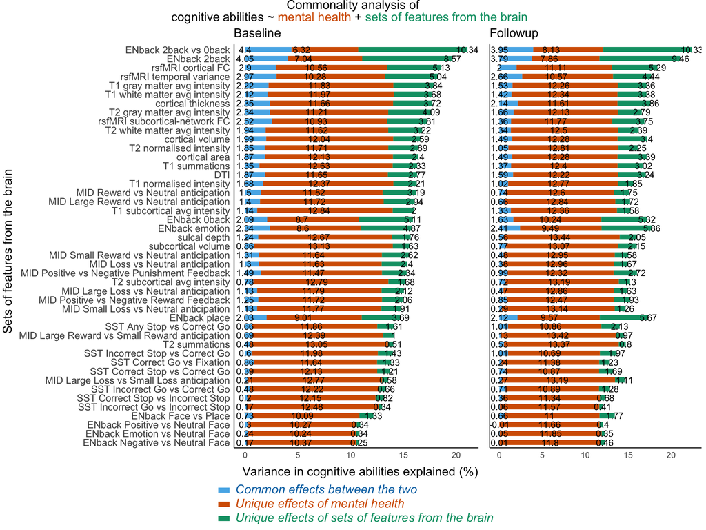

```r
## the plot to get the legend
baseline_enet_plot <- ggplot(common_enet_baseline_reordered_all, aes(x = text_coor, y=plotting_name, colour = variable ))+
geom_linerange(aes(xmin = low, xmax = upp),linewidth =3) +
geom_text(aes(x=text_coor,y=plotting_name,label=text_val),colour="black",vjust=0.5) +
scale_colour_manual(name=NULL,
                    values=c(common = "#56B4E9", psy = "#D55E00", brain = "#009E73"),
                    labels=c(
                    common =  "<i style='color:#0072B2'>Common effects between the two</i>",
                    psy = "<i style='color:#D55E00'>Unique effects of mental health</i>",
                    brain="<i style='color:#009E73'>Unique effects of sets of features from the brain</i>"))+
  labs(
    title = "Commonality analysis of
    <span style='font-size:11pt'>cognitive abilities ~
    <span style='color:#D55E00;'>mental health</span> +
   <span style='color:#009E73;'>sets of features from the brain</span>
    </span>",
    x = "Baseline", y = NULL
  ) +
  theme_minimal() +
  guides(colour = guide_legend(nrow = 3))+
theme(legend.position = "bottom",
      plot.title = element_markdown(lineheight = 1,size = 15),
    legend.text = element_markdown(size = 15)
    ,panel.grid.major = element_blank(),
    panel.grid.minor = element_blank(),
panel.background = element_blank(),
axis.line = element_line(colour = "black"),
axis.title.x = element_text(size = 10),
  axis.text.x = element_text(size = 10),
  axis.title.y = element_blank(),
  axis.text.y = element_text(size = 12)
  )

plot_enet_legend <- ggpubr::get_legend(baseline_enet_plot)


### get the two align plot

baseline_enet_plot<- ggplot(common_enet_baseline_reordered_all, aes(x = text_coor, y=plotting_name, colour = variable ))+
geom_linerange(aes(xmin = low, xmax = upp),linewidth =3) +
geom_text(aes(x=text_coor,y=plotting_name,label=text_val),colour="black",vjust=0.5) +
scale_colour_manual(name=NULL,
                    values=c(common = "#56B4E9", psy = "#D55E00", brain ="#009E73" ),
                    labels=c(
                    common =  "<i style='color:#0072B2'>Common effects between the two</i>",
                    psy = "<i style='color:#D55E00'>Unique effects of mental health</i>",
                    brain="<i style='color:#009E73'>Unique effects of sets of features from the brain</i>"))+
  labs(
    title = "Baseline",
    y = NULL, x = NULL
  ) +
  theme_minimal() +
  guides(colour = guide_legend(nrow = 3))+
theme(plot.title = element_markdown(lineheight = 1,size = 15),
    legend.text = element_markdown(size = 15)
    ,panel.grid.major = element_blank(),
    panel.grid.minor = element_blank(),
panel.background = element_blank(),
axis.line = element_line(colour = "black"),
axis.title.x = element_text(size = 10),
  axis.text.x = element_text(size = 10),
  axis.title.y = element_blank(),
  axis.text.y = element_text(size = 12),
legend.position = "none"
  )

followup_enet_plot<- ggplot(common_enet_followup_reordered_baseline, aes(x = text_coor, y=plotting_name, colour = variable ))+
geom_linerange(aes(xmin = low, xmax = upp),linewidth =3) +
geom_text(aes(x=text_coor,y=plotting_name,label=text_val),colour="black",vjust=0.5) +
scale_colour_manual(name=NULL,
                    values=c(common = "#56B4E9", psy = "#D55E00", brain = "#009E73"),
                    labels=c(
                    common =  "<i style='color:#0072B2'>Common effects between the two</i>",
                    psy = "<i style='color:#D55E00'>Unique effects of mental health</i>",
                    brain="<i style='color:#009E73'>Unique effects of sets of features from the brain</i>"))+
  labs(
    title = "Followup",
    y = NULL, x = NULL
  ) +
  theme_minimal() +
  guides(colour = guide_legend(nrow = 3))+
theme(plot.title = element_markdown(lineheight = 1,size = 15),
    legend.text = element_markdown(size = 15)
    ,panel.grid.major = element_blank(),
    panel.grid.minor = element_blank(),
panel.background = element_blank(),
axis.line = element_line(colour = "black"),
axis.title.x = element_text(size = 10),
  axis.text.x = element_text(size = 10),
  axis.title.y = element_blank(),
  axis.text.y = element_blank(),
legend.position = "none"
  )




both_enet_plot <- ggpubr::ggarrange(baseline_enet_plot, followup_enet_plot, widths = c(2.1, 1),heights = c(1,1),
          ncol = 2, nrow = 1
          #,common.legend=TRUE,legend = "top"
          )


baseline_followup_enet_plot <- ggpubr::annotate_figure(both_enet_plot,
                bottom = text_grob("Variance in cognitive abilities explained (%)", size = 15),
                left = text_grob("Sets of features from the brain", size = 15, rot = 90)
                )+
  labs(title =  "Commonality analysis of
    <span style='font-size:15pt'>cognitive abilities ~
    <span style='color:#D55E00;'>mental health</span> +
   <span style='color:#009E73;'>sets of features from the brain</span>
    </span>",
    x = NULL, y = NULL
  )+
theme(legend.position = "none",
      plot.title = element_markdown(lineheight = 1,size = 15))


 ggpubr::ggarrange(baseline_followup_enet_plot, widths = c(1, 1),heights = c(1,1),
          ncol = 1, nrow = 1,legend.grob = plot_enet_legend,legend = "bottom"
          #,common.legend=TRUE
          )
```

plotting the modalities by the descending order

```r
## check whether the modalities have the same ranking

print(common_enet_baseline_order_vec == common_enet_followup_order_vec)
```

```
##  [1] FALSE FALSE FALSE FALSE FALSE FALSE  TRUE FALSE FALSE FALSE FALSE FALSE
## [13] FALSE FALSE FALSE FALSE FALSE FALSE FALSE FALSE FALSE FALSE FALSE FALSE
## [25] FALSE FALSE FALSE FALSE FALSE FALSE FALSE FALSE FALSE FALSE FALSE FALSE
## [37] FALSE FALSE FALSE FALSE FALSE FALSE  TRUE  TRUE  TRUE
```

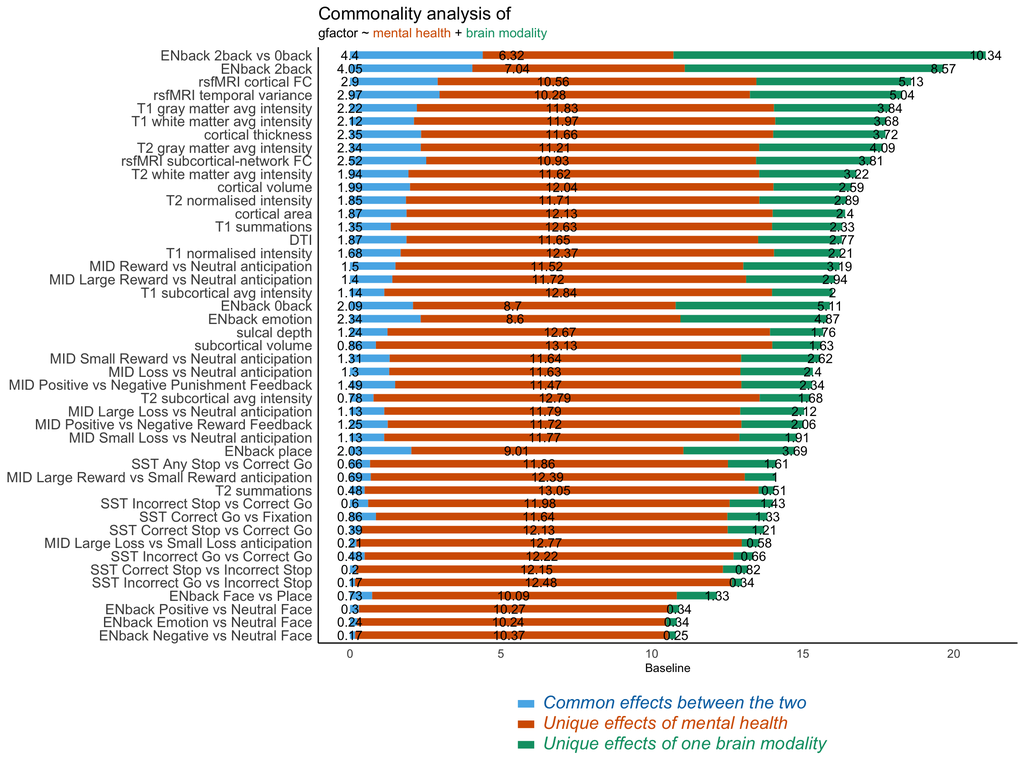

```r
ggplot(common_enet_baseline_reordered_all, aes(x = text_coor, y=plotting_name, colour = variable ))+
geom_linerange(aes(xmin = low, xmax = upp),linewidth =3) +
geom_text(aes(x=text_coor,y=plotting_name,label=text_val),colour="black",vjust=0.5) +
scale_colour_manual(name=NULL,
                    values=c(common = "#56B4E9", psy = "#D55E00", brain = "#009E73"),
                    labels=c(
                    common =  "<i style='color:#0072B2'>Common effects between the two</i>",
                    psy = "<i style='color:#D55E00'>Unique effects of mental health</i>",
                    brain="<i style='color:#009E73'>Unique effects of one brain modality</i>"))+
  labs(
    title = "Commonality analysis of
    <span style='font-size:11pt'>gfactor ~
    <span style='color:#D55E00;'>mental health</span> +
   <span style='color:#009E73;'>brain modality</span>
    </span>",
    x = "Baseline", y = NULL
  ) +
  theme_minimal() +
  guides(colour = guide_legend(nrow = 3))+
theme(legend.position = "bottom",
      plot.title = element_markdown(lineheight = 1,size = 15),
    legend.text = element_markdown(size = 15)
    ,panel.grid.major = element_blank(),
    panel.grid.minor = element_blank(),
panel.background = element_blank(),
axis.line = element_line(colour = "black"),
axis.title.x = element_text(size = 10),
  axis.text.x = element_text(size = 10),
  axis.title.y = element_blank(),
  axis.text.y = element_text(size = 12)
  )
```

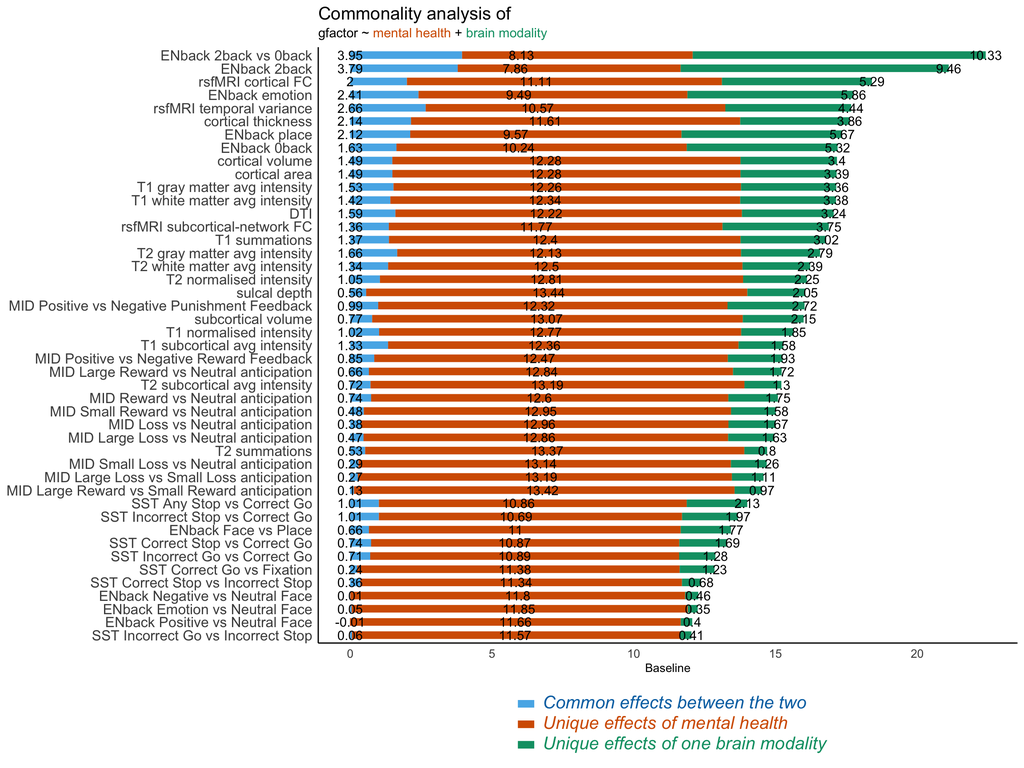

```r
ggplot(common_enet_followup_reordered_all, aes(x = text_coor, y=plotting_name, colour = variable ))+
geom_linerange(aes(xmin = low, xmax = upp),linewidth =3) +
geom_text(aes(x=text_coor,y=plotting_name,label=text_val),colour="black",vjust=0.5) +
scale_colour_manual(name=NULL,
                    values=c(common = "#56B4E9", psy = "#D55E00", brain ="#009E73" ),
                    labels=c(
                    common =  "<i style='color:#0072B2'>Common effects between the two</i>",
                    psy = "<i style='color:#D55E00'>Unique effects of mental health</i>",
                    brain="<i style='color:#009E73'>Unique effects of one brain modality</i>"))+
  labs(
    title = "Commonality analysis of
    <span style='font-size:11pt'>gfactor ~
    <span style='color:#D55E00;'>mental health</span> +
   <span style='color:#009E73;'>brain modality</span>
    </span>",
    x = "Baseline", y = NULL
  ) +
  theme_minimal() +
  guides(colour = guide_legend(nrow = 3))+
theme(legend.position = "bottom",
      plot.title = element_markdown(lineheight = 1,size = 15),
    legend.text = element_markdown(size = 15)
    ,panel.grid.major = element_blank(),
    panel.grid.minor = element_blank(),
panel.background = element_blank(),
axis.line = element_line(colour = "black"),
axis.title.x = element_text(size = 10),
  axis.text.x = element_text(size = 10),
  axis.title.y = element_blank(),
  axis.text.y = element_text(size = 12)
  )
```